# Stat 206 Final Project

STAT 206

Author

Ha Pham

Published

December 1, 2024

# Project and Description:

## 2. Methods:

One common but very effective model for relating some input metrics $\mathbf{x}$ to an output estimate $\mathbf{y}$ is by using **Linear Regression**.

$$\mathbf{a} \mathbf{x} + \mathbf{b} = \mathbf{y}$$
where $\mathbf{a}$ is the linear coefficient and $\mathbf{b}$ is the bias or intercept. Furthermore, one common loss function used to evaluate the training of this model prediction is by using Least Squares:

$$\min_{\beta}~ \|\mathbf{y} - \mathbf{X}\beta\|^{2}$$

- *Weighted Least Squares.* This is useful if you believe in addition to the input metric X, there is some other metrics $\mathbf{w}$ that effectively skew how much we should emphasize the impact of this training prediction instance on our overall model.

[output not shown]

# Data Exploration

## 1. Reading data

You see that these statistics are by district of houses, not per house. First impression from looking at dataset, total rooms and bedrooms should correlate to population in the district. It seems median_income of the district would have highest correlation to median_house_value, which is our model prediction. Ocean proximity is some sets of characters that currently don’t mean anything. Longitude and Latitude by themselves are not very meaningful for predicting house price.

```r
house_data <- read.csv(file="housing_data.csv")
summary(house_data)
```

```
   longitude         latitude     housing_median_age  total_rooms
 Min.   :-124.3   Min.   :32.54   Min.   : 1.00      Min.   :    2
 1st Qu.:-121.8   1st Qu.:33.93   1st Qu.:18.00      1st Qu.: 1448
 Median :-118.5   Median :34.26   Median :29.00      Median : 2127
 Mean   :-119.6   Mean   :35.63   Mean   :28.64      Mean   : 2636
 3rd Qu.:-118.0   3rd Qu.:37.71   3rd Qu.:37.00      3rd Qu.: 3148
 Max.   :-114.3   Max.   :41.95   Max.   :52.00      Max.   :39320

 total_bedrooms     population      households     median_income
 Min.   :   1.0   Min.   :    3   Min.   :   1.0   Min.   : 0.4999
 1st Qu.: 296.0   1st Qu.:  787   1st Qu.: 280.0   1st Qu.: 2.5634
 Median : 435.0   Median : 1166   Median : 409.0   Median : 3.5348
 Mean   : 537.9   Mean   : 1425   Mean   : 499.5   Mean   : 3.8707
 3rd Qu.: 647.0   3rd Qu.: 1725   3rd Qu.: 605.0   3rd Qu.: 4.7432
 Max.   :6445.0   Max.   :35682   Max.   :6082.0   Max.   :15.0001
 NA's   :207
 ocean_proximity    median_house_value
 Length:20640       Min.   : 14999
 Class :character   1st Qu.:119600
 Mode  :character   Median :179700
                    Mean   :206856
                    3rd Qu.:264725
                    Max.   :500001
```

```r
colnames(house_data)
```

```
 [1] "longitude"          "latitude"           "housing_median_age"
 [4] "total_rooms"        "total_bedrooms"     "population"
 [7] "households"         "median_income"      "ocean_proximity"
[10] "median_house_value"
```

```r
dim(house_data)
```

```
[1] 20640    10
```

## 2. Data Cleanup

Check if there is any Null value in the dataset and remove them from the dataset

```r
count_rows_with_null <- function(df) {
  sum(apply(df, 1, function(row) any(is.na(row))))
}
count_rows_with_null(house_data)
```

```
[1] 207
```

```r
clean_index <- vector()
for (i in 1:nrow(house_data)) {
  if (any(is.na(house_data[i,]))){
    clean_index <- append(clean_index,FALSE)
  }
  else{
    clean_index <- append(clean_index,TRUE)

  }
}
house_data <- house_data[clean_index,]
dim(house_data)
```

```
[1] 20433    10
```

Notice that the column “ocean_proximity” is currently some sets of characters which is not very useful. We convert these to categorical values.

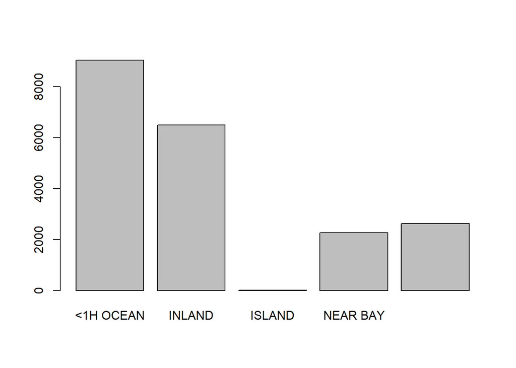

```r
# turn character column "ocean_proximity" into factors
house_data$ocean_proximity <- as.factor(house_data$ocean_proximity)
plot(house_data$ocean_proximity)
```

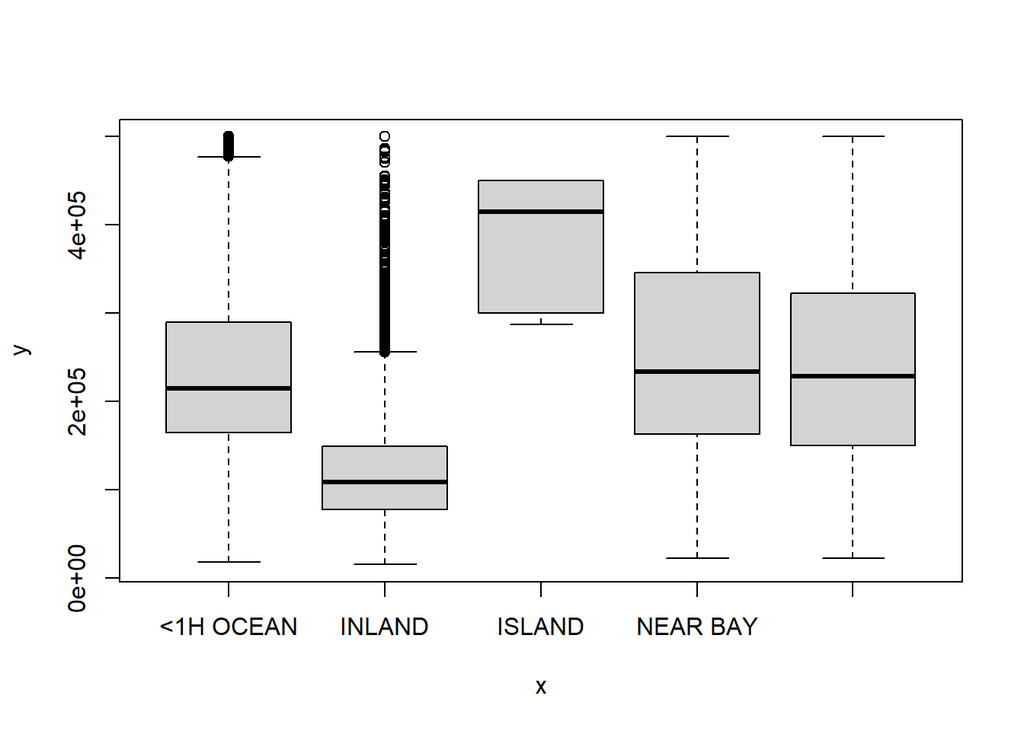

```r
plot(house_data$ocean_proximity, house_data$median_house_value)
```

## 3. Handling Outlier

Let’s plot the median_income versus median_house_value

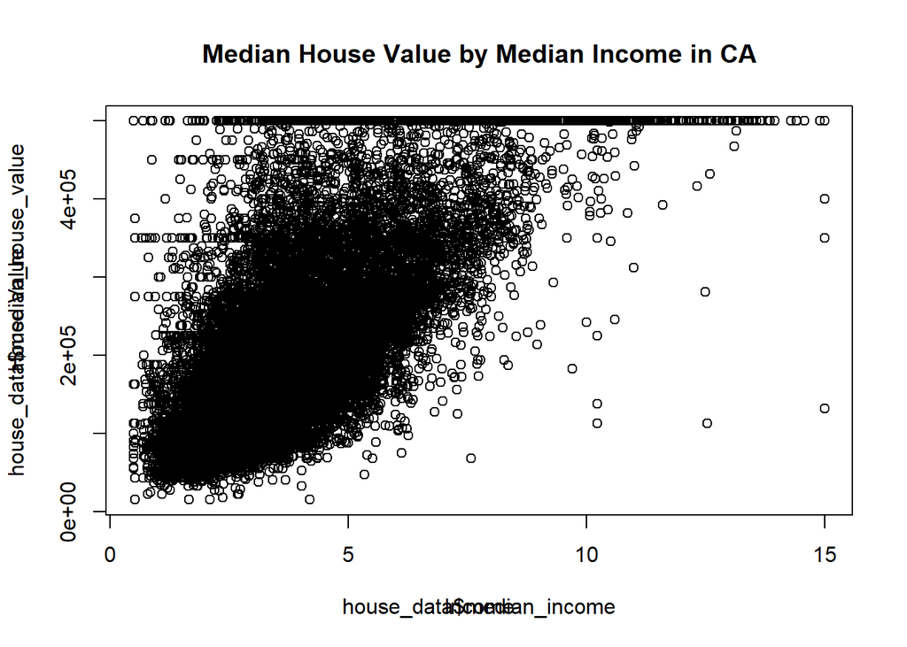

```r
plot(house_data$median_income,house_data$median_house_value)
title(main="Median House Value by Median Income in CA",
      xlab = "Income",
      ylab = "House Value")
```

Here we see that individual with the top median_income of >14 are outliers in the dataset, so let’s remove them

```r
house_data <- house_data[house_data$median_income<=14,]
dim(house_data)
```

```
[1] 20377    10
```

We can also see that there is a set of houses that have really high prices not explainable by median income. We also remove those outliers

```r
house_data <- house_data[house_data$median_house_value<=4.5e5,]
dim(house_data)
```

```
[1] 19183    10
```

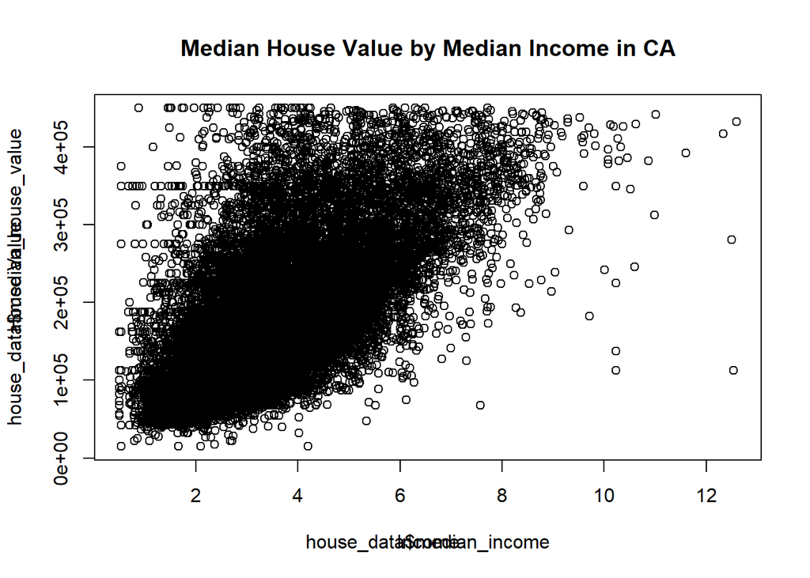

```r
plot(house_data$median_income,house_data$median_house_value)
title(main="Median House Value by Median Income in CA",
      xlab = "Income",
      ylab = "House Value")
```

## 4. Establish biase

In order to help us hone in on which metrics to prioritize in our model, let’s first do a quick generalized linear model fit of the dataset so far

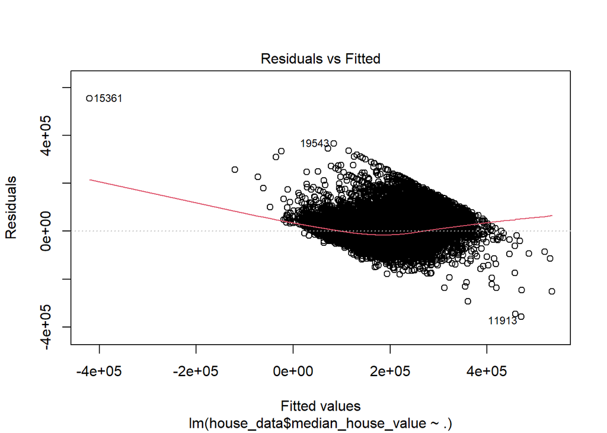

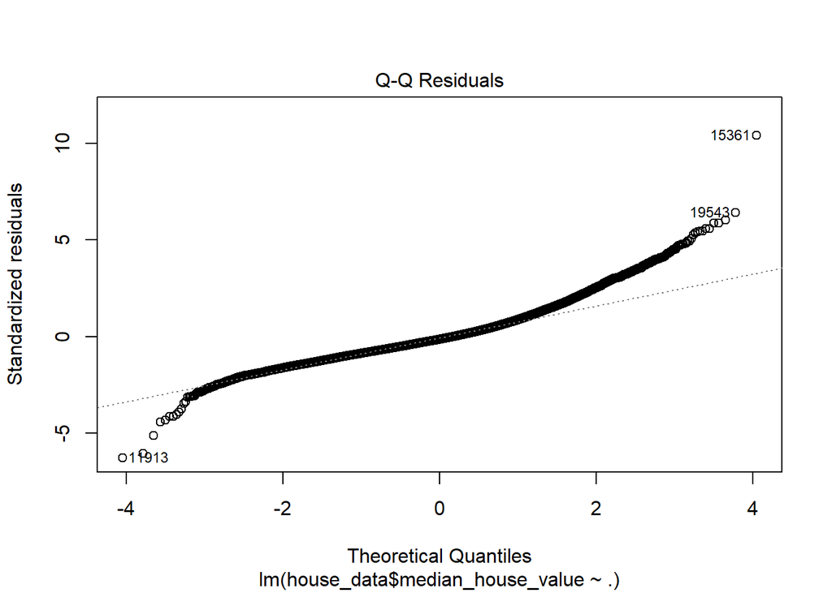

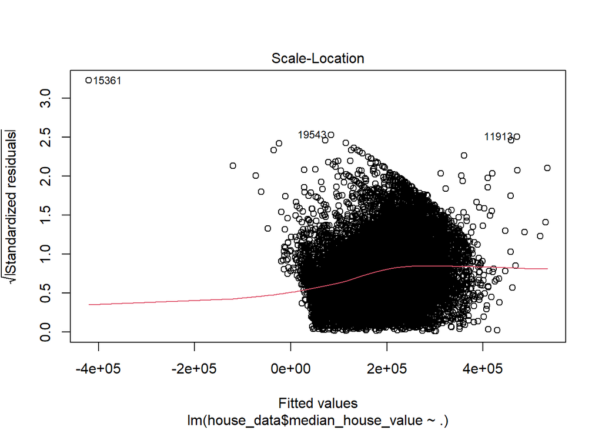

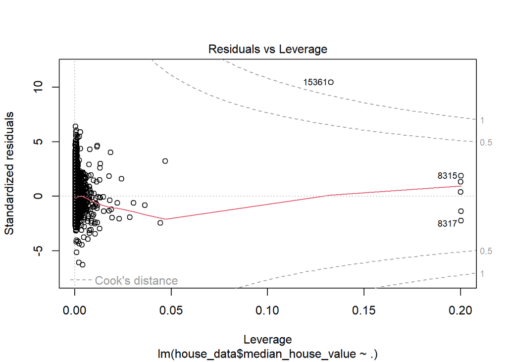

```r
lm_model <- lm(house_data$median_house_value ~ ., data = house_data)
plot(lm_model)
```

```r
summary(lm_model)
```

```
Call:
lm(formula = house_data$median_house_value ~ ., data = house_data)

Residuals:
    Min      1Q  Median      3Q     Max
-358238  -36543   -8114   27225  554691

Coefficients:
                            Estimate Std. Error t value Pr(>|t|)
(Intercept)               -2.044e+06  7.443e+04 -27.459  < 2e-16 ***
longitude                 -2.389e+04  8.617e+02 -27.724  < 2e-16 ***
latitude                  -2.176e+04  8.464e+02 -25.710  < 2e-16 ***
housing_median_age         7.984e+02  3.862e+01  20.673  < 2e-16 ***
total_rooms               -7.092e+00  7.134e-01  -9.941  < 2e-16 ***
total_bedrooms             8.687e+01  5.935e+00  14.637  < 2e-16 ***
population                -2.780e+01  9.181e-01 -30.279  < 2e-16 ***
households                 3.967e+01  6.296e+00   6.300 3.05e-10 ***
median_income              3.695e+04  3.708e+02  99.664  < 2e-16 ***
ocean_proximityINLAND     -3.914e+04  1.473e+03 -26.571  < 2e-16 ***
ocean_proximityISLAND      1.694e+05  2.556e+04   6.630 3.45e-11 ***
ocean_proximityNEAR BAY   -8.220e+03  1.663e+03  -4.944 7.71e-07 ***
ocean_proximityNEAR OCEAN  2.138e+03  1.376e+03   1.554     0.12
---
Signif. codes:  0 '***' 0.001 '**' 0.01 '*' 0.05 '.' 0.1 ' ' 1

Residual standard error: 57080 on 19170 degrees of freedom
Multiple R-squared:  0.6154,    Adjusted R-squared:  0.6151
F-statistic:  2556 on 12 and 19170 DF,  p-value: < 2.2e-16
```

- This linear fit confirms our observation that median_house_value in a district correlates most greatly with median_income.
- There seem to also be some difference in variances of ocean_proximity

# Implementation

## Preparing the test data:

### 1. Exact group variance

```r
# One method we will use is assign weights to the least squares loss function, using the variances of each
# ocean_proximity group.
# In this code, we calculate the sample price variances according to each ocean_proximity category
# NOTE: variance is the squared difference from the mean, so it makes sense to be this high!
house_data$prox_price_variance <- ave(house_data$median_house_value,house_data$ocean_proximity,FUN = var)
summary(house_data)
```

```
   longitude         latitude     housing_median_age  total_rooms
 Min.   :-124.3   Min.   :32.54   Min.   : 1.00      Min.   :    2
 1st Qu.:-121.8   1st Qu.:33.93   1st Qu.:18.00      1st Qu.: 1437
 Median :-118.5   Median :34.27   Median :28.00      Median : 2105
 Mean   :-119.6   Mean   :35.66   Mean   :28.31      Mean   : 2614
 3rd Qu.:-118.0   3rd Qu.:37.73   3rd Qu.:37.00      3rd Qu.: 3113
 Max.   :-114.3   Max.   :41.95   Max.   :52.00      Max.   :39320
 total_bedrooms     population      households   median_income
 Min.   :   2.0   Min.   :    3   Min.   :   2   Min.   : 0.4999
 1st Qu.: 297.0   1st Qu.:  798   1st Qu.: 282   1st Qu.: 2.5160
 Median : 436.0   Median : 1182   Median : 411   Median : 3.4231
 Mean   : 539.6   Mean   : 1443   Mean   : 501   Mean   : 3.6384
 3rd Qu.: 647.5   3rd Qu.: 1747   3rd Qu.: 605   3rd Qu.: 4.5430
 Max.   :6445.0   Max.   :35682   Max.   :6082   Max.   :12.5915
   ocean_proximity median_house_value prox_price_variance
 <1H OCEAN :8350   Min.   : 14999     Min.   :4.100e+09
 INLAND    :6456   1st Qu.:115550     1st Qu.:4.100e+09
 ISLAND    :   5   Median :171700     Median :6.492e+09
 NEAR BAY  :2017   Mean   :188175     Mean   :6.270e+09
 NEAR OCEAN:2355   3rd Qu.:243600     3rd Qu.:6.492e+09
                   Max.   :450000     Max.   :9.178e+09
```

```r
mean_median_house_value <- mean(house_data$median_house_value)
house_data$group_means <- house_data$median_house_value/mean_median_house_value
summary(house_data)
```

```
   longitude         latitude     housing_median_age  total_rooms
 Min.   :-124.3   Min.   :32.54   Min.   : 1.00      Min.   :    2
 1st Qu.:-121.8   1st Qu.:33.93   1st Qu.:18.00      1st Qu.: 1437
 Median :-118.5   Median :34.27   Median :28.00      Median : 2105
 Mean   :-119.6   Mean   :35.66   Mean   :28.31      Mean   : 2614
 3rd Qu.:-118.0   3rd Qu.:37.73   3rd Qu.:37.00      3rd Qu.: 3113
 Max.   :-114.3   Max.   :41.95   Max.   :52.00      Max.   :39320
 total_bedrooms     population      households   median_income
 Min.   :   2.0   Min.   :    3   Min.   :   2   Min.   : 0.4999
 1st Qu.: 297.0   1st Qu.:  798   1st Qu.: 282   1st Qu.: 2.5160
 Median : 436.0   Median : 1182   Median : 411   Median : 3.4231
 Mean   : 539.6   Mean   : 1443   Mean   : 501   Mean   : 3.6384
 3rd Qu.: 647.5   3rd Qu.: 1747   3rd Qu.: 605   3rd Qu.: 4.5430
 Max.   :6445.0   Max.   :35682   Max.   :6082   Max.   :12.5915
   ocean_proximity median_house_value prox_price_variance  group_means
 <1H OCEAN :8350   Min.   : 14999     Min.   :4.100e+09   Min.   :0.07971
 INLAND    :6456   1st Qu.:115550     1st Qu.:4.100e+09   1st Qu.:0.61406
 ISLAND    :   5   Median :171700     Median :6.492e+09   Median :0.91245
 NEAR BAY  :2017   Mean   :188175     Mean   :6.270e+09   Mean   :1.00000
 NEAR OCEAN:2355   3rd Qu.:243600     3rd Qu.:6.492e+09   3rd Qu.:1.29454
                   Max.   :450000     Max.   :9.178e+09   Max.   :2.39139
```

```r
library(caret)
# perform a stratified split to obtain 30% test and 70% training from the dataset
# Stratified sampling
set.seed(123)
train_index <- createDataPartition(house_data$median_house_value, p = 0.7, list = FALSE)

# Split into training and test sets
train_data <- house_data[train_index, ]
test_data <- house_data[-train_index, ]
dim(train_data)
```

```
[1] 13430    12
```

## Weighted Least Squares Implementation

The code below sets up the linear model with parameter theta, and then make an objective function with the inputs, model, and weights

```r
linear_model <- function(x, theta){
  # theta is the parameters of the linear objective function
  intercept <- theta[1]
  slope <- theta[2]
  pred <- intercept + slope * x
  return(pred)
}

# This is the weighted least squares of the Linear Model objective function
make_weighted_objective_func <- function(x,y,model,weights){
  f <- function(theta){
    residuals <- y - model(x,theta)
    # The residuals^2 is corrected by some defined weights
    sum(weights*residuals^2)
  }
  return(f)
}
```

### 1. Using sample variances grouped by ocean_proximity to calculate weights

In this implementation we use variances of median_house_value based on ocean_proximity as the weights for the objective function

```r
library(autodiffr)
group_var_weights = 1/train_data$prox_price_variance

weighted_variances_mse <- make_weighted_objective_func(train_data$median_income,train_data$median_house_value,linear_model,group_var_weights)

var_weighted_grad.mse <- function(theta){
  return(ad_grad(weighted_variances_mse,theta))
}

# initial guess, theta0
theta0 <- c(1,1)
weighted_var_fit <- optim(theta0,weighted_variances_mse,var_weighted_grad.mse,method="BFGS")
```

[output not shown]

[output not shown]

[output not shown]

[output not shown]

[output not shown]

[output not shown]

### 2. Using group means to calculate weights

```r
group_mean_weights = 1/abs(train_data$median_house_value-train_data$group_means)^2

weighted_means_mse <- make_weighted_objective_func(train_data$median_income,train_data$median_house_value,linear_model,group_mean_weights)

means_weighted_grad.mse <- function(theta){
  return(ad_grad(weighted_variances_mse,theta))
}

# initial guess, theta0
theta0 <- c(1,1)
weighted_means_fit <- optim(theta0,weighted_means_mse,means_weighted_grad.mse,method="BFGS")
```

# Conclusion

```r
cat("Optimized Sample Variance Weighted LS Intercept:", weighted_var_fit$par[1], "\n")
```

```
Optimized Sample Variance Weighted LS Intercept: 35739.5
```

```r
cat("Optimized Sample Variance Weighted LS Slope:", weighted_var_fit$par[2], "\n")
```

```
Optimized Sample Variance Weighted LS Slope: 39219.8
```

```r
cat("Optimized Sample Variance Weighted LS MSE:", weighted_var_fit$value[1], "\n")
```

```
Optimized Sample Variance Weighted LS MSE: 11005.53
```

```r
cat("Optimized Sample Variance Weighted LS steps to convergence:", weighted_var_fit$counts, "\n")
```

```
Optimized Sample Variance Weighted LS steps to convergence: 7 5
```

```r
cat("Optimized Group Means Weighted LS Intercept:", weighted_means_fit$par[1], "\n")
```

```
Optimized Group Means Weighted LS Intercept: 11147.96
```

```r
cat("Optimized Group Means Weighted LS Slope:", weighted_means_fit$par[2], "\n")
```

```
Optimized Group Means Weighted LS Slope: 45160.3
```

```r
cat("Optimized Group Means Weighted LS MSE:", weighted_means_fit$value[1], "\n")
```

```
Optimized Group Means Weighted LS MSE: 2632.153
```

```r
cat("Optimized Group Means Weighted LS Steps to convergence:", weighted_means_fit$counts, "\n")
```

```
Optimized Group Means Weighted LS Steps to convergence: 32 3
```

```r
lin_fit <- lm(train_data$median_house_value~train_data$median_income,data=train_data)
y_pred <- predict(lin_fit,test_data)
lin_fit.mse <- mean((test_data$median_house_value - y_pred)^2)
cat("Optimized Group Means Unweighted LS Intercept:", coef(lin_fit)[1], "\n")
```

```
Optimized Group Means Unweighted LS Intercept: 46996.97
```

```r
cat("Optimized Group Means Unweighted LS Slope:", coef(lin_fit)[2], "\n")
```

```
Optimized Group Means Unweighted LS Slope: 38883.78
```

```r
cat("Optimized Group Means Unweighted LS MSE:",lin_fit.mse , "\n")
```

```
Optimized Group Means Unweighted LS MSE: 12728152832
```